# ‘Seed Music’

Tom Brailey

2020-05-01

# Birds / Surfers

Earlier this month, one of my favorite guitarists, [Plini](https://www.plini.co/), made an Instagram post describing how a photograph of surfers out on the seas resembled notes on a staff, inspiring him to create a short piece of music. You can view the post and listen to an excerpt of his song “Surfers” [here](https://www.instagram.com/p/B5o6QnJFJGv/). Plini followed the same melody-generating process using an image of a flock of birds which is equally awesome.

I thought this form of melody generation was pretty neat so I decided to give it a go. But instead of using images, I thought it would be fun to make a function that generates random “notes” on a staff in ggplot2. My plan was to create the function, and whatever output it gave me, I would strive to write a full song from it. I present to you my fun quarantine project, “Seed Music”!

# theme_music()

The first step was to randomly generate point data that, when visualized, would resemble notes on a staff. This meant a lot of trial-and-error with the limits of x and y values—a note, for example, thirty octaves up from middle-C would be difficult to implement on my trusty Telecaster…

I also decided to randomly assign NA values into the data to make sure the staff was not overpopulated with notes.

I settled for the function below:

```r
generate_data <- function(){

  x <- data.frame(x = sample(0:50, 20, rep = FALSE),
             y = sample(0:12, 5, rep = FALSE))

  some_na <- sample(0:15, 1, rep = FALSE)

  x$x[sample(seq(x$x), some_na)] <- NA


  return(x)

}
```

Next, I wanted the function to spit out a random mode so that I would be forced to think creatively with the notes I was given:

```r
generate_mode <- function(){

   keys <- c("A", "A#", "B", "C", "C#", "D", "D#", "E", "F", "F#", "G", "G#")
   modes <- c("Ionian", "Dorian", "Phrygian", "Lydian", "Mixolydian", "Aeolian", "Locrian")

   x <- paste(sample(keys, 1), sample(modes, 1), sep = " ")

   return(x)

}
```

Lastly, I take the two previous functions and throw them into ggplot2. I set hlines at the 2, 4, 6, 8, and 10 values on the y-axis to create the appearance of a staff, and vlines help me to estimate how close together the notes are. This method gives me *some* flexibilty when determining the rhythm and time-signature of the melody.

```r
plot_music <- function(){

  x <- generate_data()

  key <- generate_mode()

  plot <- ggplot(x, aes(x = x, y = y)) +
    geom_point(size = 6) +
    geom_hline(yintercept = c(2, 4, 6, 8, 10), size = 2) +
    geom_vline(xintercept = c(x$x)) +
    theme(title = element_text(size = 16)) +
    labs(subtitle = key) +
    theme_void()

  ggsave(plot, filename = paste0(here::here(), "/content/posts/", key, ".png"))

  return(plot)

}
```

And here is an example of what I would be given to work with (note that every time I update my website this image will change):

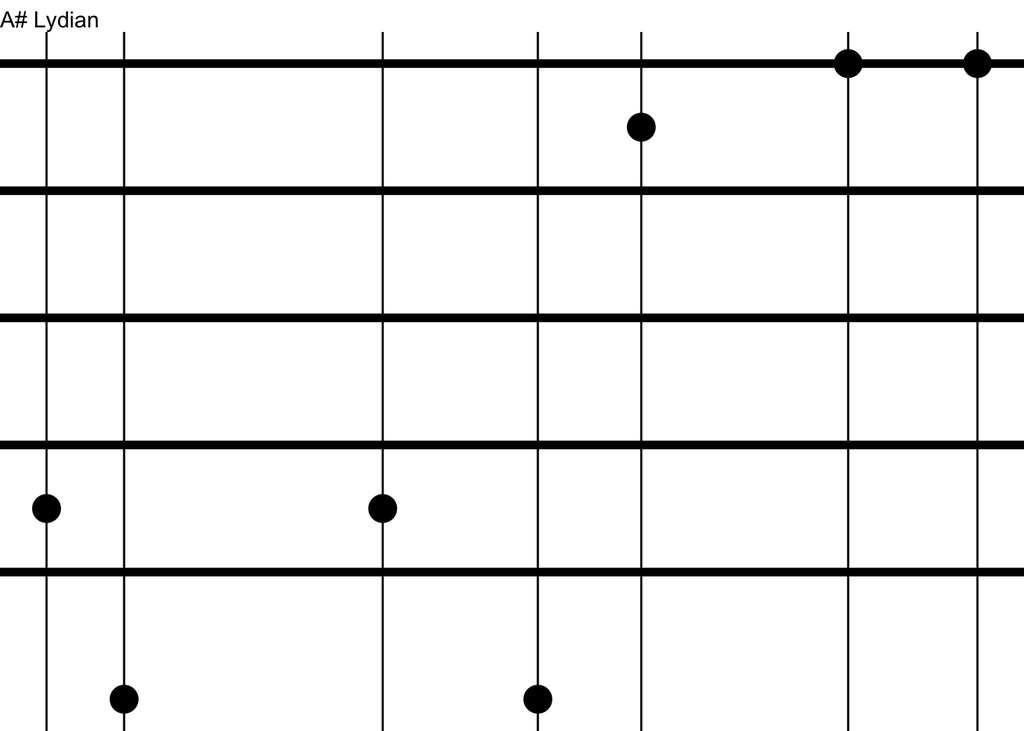

# So how does it sound?